# 第四讲 sas 宏

王宁宁

## 宏概述

- 宏以前被认为是经验老道的SAS程序员使用的高级技术。
- 宏处理器 标准SAS程序中，提交程序后，SAS就编译并立即执行。但宏语句多了一步，在提交之后，SAS会将宏语句传送到宏处理器上，将其转变为SAS标准代码，通常叫做“变换代码”（meta-programming.）
- 宏和宏变量 SAS宏代码包括两个基本部分：宏命令和宏变量。宏变量通常加一个“&”作为前缀，而宏命令通常加一个“%”作为前缀。
- 局部VS全局 宏变量有局部宏变量和全局宏变量。如果在宏的内部定义则为局部宏变量，只能在内部使用。如果在开放代码中定义则为全局宏变量。避免两种错误：在宏之外（开放代码）使用局部变量；创建同名的局部变量和全局变量。
- 启动宏处理器 使用宏指令之前必须将宏系统选项打开，尽管有时默认是打开的。可以用下面代码查看是否打开：

```
PROC OPTIONS OPTION=MACRO;
RUN;
```

查看日志，如果看到`MACRO`，则打开了；如果看到`NOMACRO`，则没有打开。

## 宏变量

- 用`%let`创建一个宏变量 最简单给宏变量分配一个值的方法是`%let`，基本形式为：

```
%LET macro-variable-name=value;
```

- 宏变量名必须符合SAS命名法则，（少于等于32字节、以字母或下划线开头、只能包括字母、数字和下划线），下面创建了宏变量：

```
  %LET iterations=10;
  %LET country=New Zealand;
```

- 当赋值字符串时，不需要加引号。除非在开头和结尾有空格，否则从等号到分号的全部内容都是变量值。
- 使用宏变量 宏变量前面要加前缀`&`，注意宏处理器找不到单引号内的宏变量，只能用双引号。如下的例子：

```
DO i=1 to &iterations;
TITLE ”Addresses in &country”;
```

经宏处理器编译后，语句变成：

```
DO i=1 to 10;
TITLE ”Addresses in New Zealand”;
```

### 例

一份关于花店销售的数据，变量为顾客ID，销售日期，花的种类，数量 想要一份反映某一种类型花的销售情况数据，宏变量就可以不用编辑数据步和过程步来选择一种花种：

TropicalSales.dat 下载

```
%LET flowertype = Heliconia;

* Read the data and subset with a macro variable;
DATA flowersales;
   INFILE 'c:\MyRawData\TropicalSales.dat';
   INPUT CustomerID $4. @6 SaleDate MMDDYY10. @17 Variety $9. Quantity;
  IF Variety = "&flowertype";
RUN;
* Print the report using a macro variable;
PROC PRINT DATA = flowersales;
   FORMAT SaleDate WORDDATE18.;
   TITLE "Sales of &flowertype";
RUN;
```

## 宏模块化代码

- 宏可以使一段代码在一个或多个程序中被反复使用，而不需要重复地去编写相同或相似的代码。基本形式为：

```
%MACRO macro-name;
macro-text
%MEND macro-name;
```

`%MACRO`语句告诉`SAS`这是宏开始，而`%MEND`则意味着结束。`macro-name`是自己命名的，但`mend`后面的`macro-name`则是可选的，但加入会使得句子好很多（easier to debug and maintain）。

- 启动宏 定义了宏之后，可以通过在宏名称前面增加`%`来启动宏：`%macro-name`，注意这里可以不用分号。

### 例子

使用前面花店销售的数据：

下面的代码创建了一个名为`%SAMPLE`的宏，来将数据按照`Quantity`排序，打印出最大销售额的五个观测值（先降序排列，然后用OBS指定最后一行）。然后用标准数据步读取数据，并启动宏：

```
/* Program */
* Macro to print 5 largest sales;
%MACRO sample;
   PROC SORT DATA = flowersales;
      BY DESCENDING Quantity;
   RUN;
   PROC PRINT DATA = flowersales (OBS = 5);
      FORMAT SaleDate WORDDATE18.;
      TITLE 'Five Largest Sales';
   RUN;
%MEND sample;

* Read the flower sales data;
DATA flowersales;
   INFILE 'c:\MyRawData\TropicalSales.dat';
   INPUT CustomerID $4. @6 SaleDate MMDDYY10. @17 Variety $9. Quantity;
*proc print;
RUN;

* Invoke the macro;

%sample
```

- 宏自动呼叫库 本书中的宏仅在一个程序内部定义和启动。也可以将宏储存在一个中心位置，叫做自动呼叫库，被各个程序分享。具体来说，将宏作为文件储存在某路径中，或作为分区数据集中的一员。使用`MAUTOSOURCE`和`SASAUTOS=`系统选项告诉SAS在哪里查找宏。之后，即使宏没有出现在程序中，也可以启动它。

## 宏参数

- 参数就是宏的变量，给宏增加参数，在%MACRO语句中的括号内列出宏变量的名字。基本形式为：

```
%MACRO macro-name(parameter-1=,parameter-2=,...parameter-n=);
macro-text
%MEND macro-name;
```

- 比如，一个叫做`%QUARTERLYREPORT`的宏可能这样开始：

```
%MACRO quarterlyreport(quarter=,salesrep=);
```

- 这个宏有两个参数`&QUARTER` 和`&SALESREP`。启用这个宏可以用这样的语句：

```
%quarterlyreport(quarter=3,salesrep=Smith)
```

### 例子

```
/* Program */
* Macro with parameters;
%MACRO select(customer=,sortvar=);
   PROC SORT DATA = flowersales OUT = salesout;
      BY &sortvar;
      WHERE CustomerID = "&customer";
   RUN;
   PROC PRINT DATA = salesout;
      FORMAT SaleDate WORDDATE18.;
      TITLE1 "Orders for Customer Number &customer";
      TITLE2 "Sorted by &sortvar";
   RUN;
%MEND select;


* Read all the flower sales data;
DATA flowersales;
   INFILE 'c:\MyRawData\TropicalSales.dat';
   INPUT CustomerID $4. @6 SaleDate MMDDYY10. @17 Variety $9. Quantity;
RUN;

*Invoke the macro;
%select(customer = 356W, sortvar = Quantity)
%select(customer = 240W, sortvar = Variety)
```

## 使用条件逻辑写宏代码

- 在宏中使用条件逻辑的基本形式为：

```
%IF condition %THEN action;
%ELSE %IF condition %THEN action;
%ELSE action;
%IF condition %THEN %DO;
SAS statements
%END;
```

- 自动宏变量 每一次启动SAS，宏处理器自动创建一些宏变量，可以使用在程序中。最常见的有：
  - &SYSDAY
  - &SYSDATE

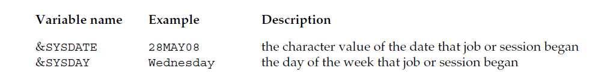

- 比如，可以像这样结合自动宏变量和条件逻辑语句：

```
%IF &SYSDAY=Tuesday %THEN %LET country=Belgium;
%ELSE %LET country=France;
```

### 例子

[output not shown]